# Experiment 0 pilot

Matt Green

This document aims to be a complete and up to date record of the analysis for vagueness 0, the pilot experiment.

Knitr doc options.

```r
library(knitr)
knit_hooks$set(crop=hook_pdfcrop)
```

Load libraries.

```r
suppressPackageStartupMessages(library(MASS))
suppressPackageStartupMessages(library(knitr))
suppressPackageStartupMessages(library(ggplot2))
suppressPackageStartupMessages(library(lme4))
suppressPackageStartupMessages(library(xtable))
suppressPackageStartupMessages(library(plyr))
suppressPackageStartupMessages(library(reshape))
suppressPackageStartupMessages(library(lattice))
suppressPackageStartupMessages(library(LMERConvenienceFunctions))
suppressPackageStartupMessages(library(car))
suppressPackageStartupMessages(library(gridExtra))
suppressPackageStartupMessages(library(grid))
suppressPackageStartupMessages(library(lmerTest))
```

Source additional R files with functions for computing confidence intervals.

```r
source("CIfunctions.R")
```

# Preprocessing

Get the data.

```r
if( file.exists('data.txt') )
    {
    d <- read.table("data.txt", header=FALSE)
} else {
    system("cat ../experimentCode/output/*.dat > data.txt", wait=TRUE)
}
mynames <- list("gap", "target", "side", "vagueness", "pair", "Version", "Left",
                                "Right", "Text", "Condition", "correctAnswer", "subject",
                                "actualAnswer", "isCorrect", "rt")
names(d) <- mynames
d$obs <- 1:nrow(d)
d$trial <- 0
for (s in unique(d$subject)){
  d[d$subject==s, "trial"] <- 1:nrow(subset(d,subject==s))
}
# For some reason there is one rt of -6. Set it to NA
d[d$rt==-6,"rt"] <- NA
# make a df
d <- data.frame(
  obs = d$obs,
  trial = d$trial,
  subject = d$subject,
  item = factor(d$pair, label = c("2:4", "3:5", "6:8", "7:9", "2:6", "7:3", "8:4", "5:9")),
  gap = factor(d$gap, levels = c("BigGap", "SmallGap"), labels = c("Big Gap", "Small Gap")),
  quan = factor(d$target, levels = c("BigTarget", "SmallTarget"), labels = c("Big Target", "Small Target")),
  vag = factor(d$vagueness, levels = c("Precise", "Vague"), labels = c("Crisp", "Vague")),
  side = d$side,
  err = 1 - d$isCorrect,
  rt = d$rt)
d$subit <- "Not subitizable"
d$subit[d$item == "2:4"] <- "Subitizable"
d$subit[d$item == "3:5"] <- "Subitizable"
d$subit[d$item == "2:6"] <- "Subitizable"
d$subit[d$item == "7:3"] <- "Subitizable"
d$subit = as.factor(d$subit)
d <- subset(d, select = c("obs", "trial", "subject", "item", "gap", "quan",
                          "vag", "subit", "side", "err", "rt"))
```

```r
# by setting the RT to NA
d[d$err==1,"rt"] <- NA
```

Do some factors and contrasts. Set subject and item as factors. Sum code vagueness and subitizability.

```r
d$subject <- as.factor(d$subject)
d$item <- as.factor(d$item)
d$vag <- relevel(d$vag, ref="Vague")
contrasts(d$vag) <- contr.sum(2)/2
d$subit <- relevel(d$subit, ref="Subitizable")
contrasts(d$subit) <- contr.sum(2)/2
contrasts(d$quan) <- contr.sum(2)/2
contrasts(d$gap) <- contr.sum(2)/2
```

Check the contrasts.

```r
contrasts(d$vag)
```

```
##       [,1]
## Vague  0.5
## Crisp -0.5
```

```r
contrasts(d$subit)
```

```
##                 [,1]
## Subitizable      0.5
## Not subitizable -0.5
```

```r
contrasts(d$quan)
```

```
##              [,1]
## Big Target    0.5
## Small Target -0.5
```

```r
contrasts(d$gap)
```

```
##           [,1]
## Big Gap    0.5
## Small Gap -0.5
```

Add transformations of rt

```r
d$logRT <- log(d$rt)
d$recipRT <- -10000/d$rt
```

For the untrimmed data, show effects of transforming rt.

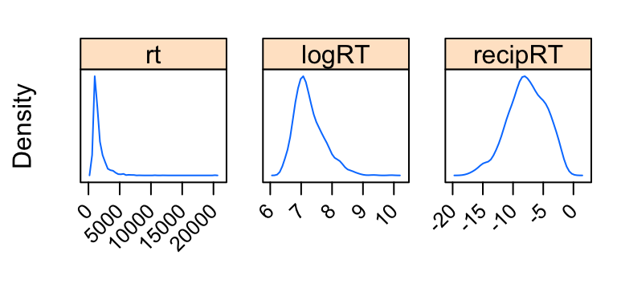

```r
xs = melt(d,
                    measure.vars = c("rt","logRT","recipRT"))
densityplot(
    ~value|variable,
    data=xs,
    xlab=NULL,
    yaxt=F,
  scales=list(x=list(relation="free", rot=45),
                        y=list(relation="free", at=NULL)),
    cex=.2,
    plot.points=FALSE,
    layout=c(3,1)
    )
```

Trim the data. This function doesn’t work well if there are NA values in the response, so explicitly remove them first.

```r
dummy <- subset(d, !is.na(rt))
data.trim <- perSubjectTrim.fnc(dummy, response="rt",subject="subject", trim=2.5)$data
```

```
## ......
## n.removed = 60
## percent.removed = 3.848621
```

Check the distribution of the trimmed data to see if a transformation is suggested.

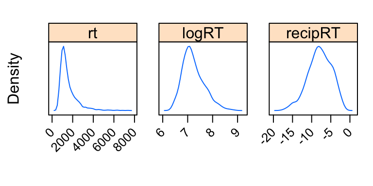

```r
xs = melt(data.trim,
                    measure.vars = c("rt","logRT","recipRT"))
densityplot(
    ~value|variable,
    data=xs,
    xlab=NULL,
    yaxt=F,
  scales=list(x=list(relation="free", rot=45),
                        y=list(relation="free", at=NULL)),
    cex=.2,
    plot.points=FALSE,
    layout=c(3,1)
    )
```

Select either trimmed or untrimmed data by comparing this plot with the untrimmed data. Also use this plot to choose the most normal data (logRT).

```r
dat <- data.trim
```

# RT modelling

Do a first lmer model. You can’t put subit or gap over items because they are between-items.

```r
lmer2 <- lmer(data=dat, logRT~subit*vag + (subit*vag|subject) + (vag|item))
# lmer3 is closer to the original anova than lmer2
lmer3 <- lmer(data=dat, logRT~subit*vag+quan+gap + (subit*vag|subject) + (vag|item))
```

```r
print(xtable(summary(lmer3)$coefficients, digits=3), type="html")
```

|  | Estimate | Std. Error | df | t value | Pr(>\|t\|) |
| --- | --- | --- | --- | --- | --- |
| (Intercept) | 7.242 | 0.067 | 29.047 | 108.801 | 0.000 |
| subit1 | -0.303 | 0.062 | 6.695 | -4.867 | 0.002 |
| vag1 | 0.017 | 0.021 | 11.583 | 0.809 | 0.435 |
| quan1 | 0.084 | 0.013 | 1418.854 | 6.464 | 0.000 |
| gap1 | -0.211 | 0.044 | 6.977 | -4.758 | 0.002 |
| subit1:vag1 | 0.172 | 0.037 | 8.653 | 4.640 | 0.001 |

## subitizable

```r
print(xtable(summary(lmer(data=dat, subset=subit=="Subitizable",logRT~vag+quan+gap +(vag|subject)+(vag|item)))$coefficients, digits=3), type='html')
```

|  | Estimate | Std. Error | df | t value | Pr(>\|t\|) |
| --- | --- | --- | --- | --- | --- |
| (Intercept) | 7.090 | 0.057 | 24.999 | 125.174 | 0.000 |
| vag1 | 0.103 | 0.035 | 4.268 | 2.930 | 0.040 |
| quan1 | 0.101 | 0.017 | 729.040 | 5.935 | 0.000 |
| gap1 | -0.106 | 0.027 | 7.570 | -3.945 | 0.005 |

## not subitizable

```r
print(xtable(summary(lmer(data=dat, subset=subit=="Not subitizable", logRT~vag+quan+gap +(vag|subject)+(vag|item)))$coefficients, digits=3), type='html')
```

|  | Estimate | Std. Error | df | t value | Pr(>\|t\|) |
| --- | --- | --- | --- | --- | --- |
| (Intercept) | 7.393 | 0.073 | 23.771 | 101.200 | 0.000 |
| vag1 | -0.066 | 0.023 | 13.395 | -2.826 | 0.014 |
| quan1 | 0.066 | 0.020 | 686.225 | 3.285 | 0.001 |
| gap1 | -0.305 | 0.054 | 2.197 | -5.652 | 0.024 |

# Error rate analysis

```r
print(xtable(summary(
    glmer(data=d, err~vag*subit+quan+gap + (vag|subject) + (1|item),
                family=binomial,
                control = glmerControl(optimizer = "bobyqa")
                )
    )$coefficients,
    digits=3),
    type='html')
```

|  | Estimate | Std. Error | z value | Pr(>\|z\|) |
| --- | --- | --- | --- | --- |
| (Intercept) | -4.355 | 0.347 | -12.537 | 0.000 |
| vag1 | 0.879 | 0.583 | 1.507 | 0.132 |
| subit1 | -0.769 | 0.527 | -1.459 | 0.145 |
| quan1 | 0.215 | 0.329 | 0.653 | 0.514 |
| gap1 | -0.976 | 0.443 | -2.201 | 0.028 |
| vag1:subit1 | 2.559 | 0.880 | 2.907 | 0.004 |

# Plots of significant effects

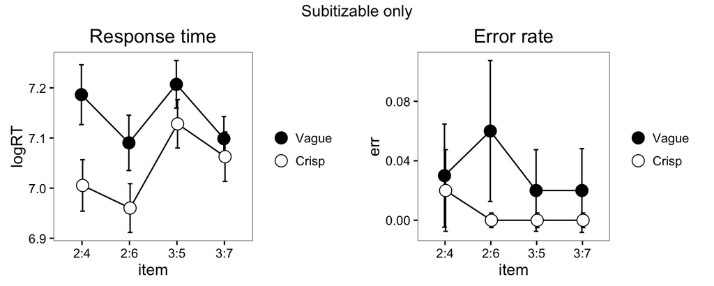

```r
a <- summarySEwithin(data=dat, measurevar="logRT", withinvars=c("vag","subit","item"), idvar="subject")
as <- subset(a,subit=="Subitizable")
as$item <- as.character(as$item)
as$item[as$item=="7:3"] <- "3:7"
as$item <- factor(as$item)
pd <- position_dodge(.05)
plot1 = ggplot(data=as, aes(y=logRT, x=item, ymin=logRT-ci, ymax=ci+logRT, fill=vag, group=vag)) +
  geom_line(position=pd) +
  geom_errorbar(width=.2, position=pd)+
  geom_point(pch=21, size=4, position=pd) +
  scale_fill_grey(name=element_blank(),start=0,end=1)+
  theme_bw()+
  theme(panel.grid.major = element_blank(), panel.grid.minor = element_blank(), legend.key=element_blank()) +
  ggtitle("Response time")

a <- summarySEwithin(data=d, measurevar="err", withinvars=c("vag","subit","item"), idvar="subject")
as <- subset(a,subit=="Subitizable")
as$item <- as.character(as$item)
as$item[as$item=="7:3"] <- "3:7"
as$item <- factor(as$item)
pd <- position_dodge(.05)
plot2 = ggplot(data=as, aes(y=err, x=item, ymin=err-ci, ymax=ci+err, group=vag, fill=vag))+
  geom_line(position=pd) +
  geom_errorbar(width=.2, position=pd)+
  geom_point(pch=21, size=4, position=pd) +
  scale_fill_grey(name=element_blank(),start=0,end=1)+
  theme_bw()+
  theme(panel.grid.major = element_blank(), panel.grid.minor = element_blank(), legend.key=element_blank()) +
  ggtitle("Error rate")

grid.arrange(plot1, plot2, nrow=1, top="Subitizable only")
```

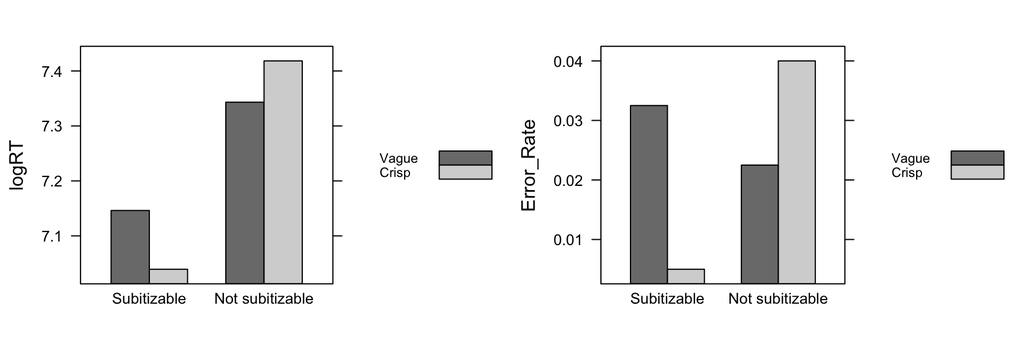

```r
bwtheme <- standard.theme("pdf", color=FALSE)
b1=barchart(data=ddply(dat,.(vag,subit),summarise, logRT=mean(logRT)),
                        logRT~subit,
                        group=vag, auto.key=list(space='right', cex=.7), par.settings=bwtheme)
b2=barchart(data=ddply(d,.(vag,subit),summarise, Error_Rate=mean(err)),
                        Error_Rate~subit,
                        group=vag, auto.key=list(space='right', cex=.7), par.settings=bwtheme)
grid.arrange(b1,b2,ncol=2)
```

Subitizability x Vagueness x Quantity

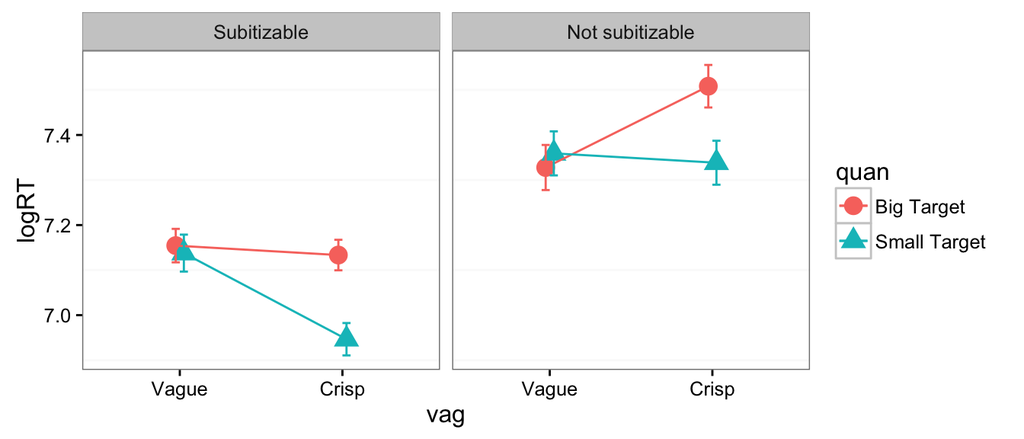

```r
a <- summarySEwithin(data=dat, measurevar="logRT", withinvars=c("vag","quan","subit"), idvar="subject")
pd <- position_dodge(.1)
    ggplot(
        a,
        aes(y=logRT, x=vag, group=quan, shape=quan, col=quan, ymin=logRT-ci, ymax=ci+logRT)
    ) +
    geom_point(size=4, position=pd) +
    geom_line(position=pd) +
    facet_grid(~subit) +
    geom_errorbar(width=.1, position=pd) +
    theme_bw() +
    theme(panel.grid.major=element_blank())
```

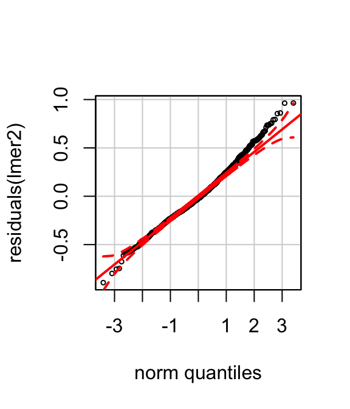

```r
qqPlot(residuals(lmer2),cex=.5)
```